# GWAS Practical Tutorial · Manuel Gentiluomo

Skip to content

GWAS  
Practical TutorialMANUEL GENTILUOMO

Your learning path

**Open learning resources**

Genetic and genomic data analysis

**GWAS Practical Tutorial** · University of Pisa

[GitHub](https://github.com/mgentiluomo/GWAS_training_session/tree/course/2026-guided-training)[Personal site](https://www.manuelgentiluomo.it/)Review draft

Genetic and genomic data analysis · University of Pisa

# From genotype data to association analysis.

A practical GWAS tutorial you can follow in class and return to at your own pace. Understand the question, run a small step, check the result.

Manuel Gentiluomo · University of Pisa

Prepare your computerStart the QC walkthrough

Module 01 · Core pathway

### Quality control

Meet the files, investigate missing calls and document which samples and variants remain.

Guided web lessonOpen the walkthrough →

Module 02 · Core pathway

### Population structure

Explore genetic similarity with PCA and prepare a defensible analysis sample set.

RStudio notebook[Open lesson 2 on GitHub →](https://github.com/mgentiluomo/GWAS_training_session/blob/course/2026-guided-training/legacy/demo_2025/02_population_structure.Rmd)

Module 03 · Core pathway

### Association

Compare logistic models and interpret odds ratios, Manhattan plots and QQ plots.

RStudio notebook[Open lesson 3 on GitHub →](https://github.com/mgentiluomo/GWAS_training_session/blob/course/2026-guided-training/legacy/demo_2025/03_association.Rmd)

## One task at a time. More than one way to keep up.

Run the core steps first. If you are ready for more, try a challenge. If your computer is blocked, read the worked outputs or use a matching checkpoint and return to the error later.

Find a way back into the lesson →

## What you need

- Basic experience opening a table in R.
- Your own Windows, macOS or Linux computer.
- R, RStudio and PLINK 2 for the analytical work.

You can read the tutorial and try its browser exercises without installing the analysis software.

## What you will produce

- An auditable QC count table.
- PCA and an explicit sample list.
- Association results and a short interpretation.

The modules can be used separately or combined. One suggested teaching route uses three four-hour sessions, including breaks.

**Practice data, clearly labelled.** This web walkthrough uses a simulated dataset: 600 samples and 6,000 variants. The original class data use a separate access route. Demo results cannot support a claim about a real disease.

## Use the modules across courses

These are independent teaching materials by Manuel Gentiluomo for students at the University of Pisa. Use a single topic, follow the complete GWAS pathway, or return to an example for self-study.

One possible teaching context is *Omics: Biotechnology and AI for Health* (552EE), in the MSc in Biotechnologies and Applied Artificial Intelligence for Health. The resource has a broader scope and can support other genetics, genomics, biotechnology and bioinformatics teaching.

Choose the preparation and file-format sections if you are new to the tools. If you already know them, move to the analytical modules and optional challenges. Teaching time and module selection can be adapted to each course.

## How to use a lesson

| Understand | Run | Check | Interpret |
| --- | --- | --- | --- |
| Read the question and the figure. | Run one R chunk in the supplied notebook. | Compare the file, shape and count. | Explain what changed and why it matters. |

← Tutorial homePrepare your computer →

Before the class

# A working starting point.

Keep your computer in your preferred language. We use explicit file conventions and a single RStudio project.

## 1. Download the complete project

Download the ZIP and extract it into a writable local folder. Open `GWAS_course.Rproj`. Keep its folders together; do not move individual notebooks into a new folder.

[Download the RStudio project](https://github.com/mgentiluomo/GWAS_training_session/archive/refs/heads/course/2026-guided-training.zip)[Browse the source on GitHub](https://github.com/mgentiluomo/GWAS_training_session/tree/course/2026-guided-training)

This preview points to the review branch. The main branch is not yet the revised course.

## 2. Install R and RStudio

Install [R](https://cran.r-project.org/) first, then [RStudio Desktop](https://docs.posit.co/ide/user/download.html). Open the project and find the R console: it usually has a `>` prompt.

R console · check the project

```
getwd()
file.exists("config.R")
```

**Check:** the second command returns `TRUE`. If not, reopen the project instead of editing paths in every lesson.

## 3. Add PLINK 2 for your system

Download from the [official PLINK 2 page](https://www.cog-genomics.org/plink/2.0/), extract the archive, and put the executable in the project’s `bin/` folder. The tested Linux build is beta 1.4, 7 November 2026; record the actual build you use.

### Windows

Select the appropriate 64-bit build. Put `plink2.exe` directly in `bin/`. Windows may hide known filename extensions: check the file type and avoid accidentally naming it `plink2.exe.exe`.

### macOS

Select ARM64 for Apple Silicon or the matching Intel build for an Intel Mac. Put `plink2` in `bin/`. If necessary, run `Sys.chmod("bin/plink2", "0755")` in the R console. Follow the standard macOS approval process for a trusted official download.

### Linux

Select a build compatible with the CPU. Put `plink2` in `bin/`. If necessary, run `Sys.chmod("bin/plink2", "0755")` in the R console. A working executable on PATH is also supported.

The analytical workflow has been executed on Linux. The Windows and macOS instructions still require checks on those systems. Do not disable system security to run a download.

## 4. Create or download the demo inputs

Leave `mode = "demo"` in `config.R`. Create the data in the R console:

R · run in RStudio

```
source("scripts/create_demo.R")
```

The final table should report **600 samples and 6000 variants**. If you cannot generate it yet, download the same input files and extract them into the project root, preserving the `data/demo/` path.

Prepare data in R

## 5. Run the pre-class check

R · run in RStudio

```
source("scripts/preflight.R")
```

The check tests the executable, input-file consistency and PLINK read/write access in a path with spaces and non-English characters. It saves `results/demo/preflight.txt`. If it stops, keep the first error and visit Troubleshooting.

## Different languages, identical file conventions

| Convention | Use | Avoid |
| --- | --- | --- |
| Decimal mark | 23.5 | 23,5 in a course numeric field |
| Column separator | Tabs in metadata TSV | Assuming every .csv uses the same delimiter |
| Thousands grouping | 12500 | 12,500 or 12.500 |
| Sample identifiers | Text, e.g. 00123 | Dropping initial zeros |
| Text encoding | UTF-8 | An undocumented export encoding |

The setup sets decimal display to a point in the current R session. It does not change your operating-system language. The importer rejects ambiguous numeric fields rather than guessing.

**Why a comma is not always a decimal mark**

In one file, `1,234` may mean one point two three four; in another, one thousand two hundred thirty-four. A blanket replacement can corrupt data. Confirm the documented delimiter and decimal convention before converting an external file.

[Read the detailed international-settings guide →](https://github.com/mgentiluomo/GWAS_training_session/blob/course/2026-guided-training/docs/international_setup.md)

## Your ready checklist

- The complete RStudio project opens, and config.R exists.
- PLINK 2 reports a working version.
- The demo BED/BIM/FAM set is present and preflight passes.
- I can distinguish the R console, terminal and notebook editor.

← Tutorial homeOpen quality control →

Module 01 · Core walkthrough

# Quality control. Keep track of every decision.

Before testing association, ask whether the genotype data are sufficiently complete and whether the samples fit the planned analysis.

Open `legacy/demo_2025/01_quality_control.Rmd` in RStudio. Read this page alongside it. Run one chunk at a time; the web page itself does not run R or PLINK.

Step 01

## Start a clean session.

Open the project and restart R. Use the notebook’s Run button if keyboard shortcuts differ on your keyboard. The first chunk loads the shared helpers and checks the matching genotype files.

R · run in RStudio

```
root <- if (file.exists("R/course.R")) "." else ".."
source(file.path(root, "R", "course.R"))
cfg <- course_config(root)
print(check_bed(cfg$input))
```

**Check:** the data mode says `demo (SIMULATED data)` and the input counts are 600 samples and 6000 variants. A missing-file error means setup is incomplete; do not run later chunks yet.

| Location | What belongs there | Example |
| --- | --- | --- |
| R console | R expressions | 2 + 2 |
| Terminal | Operating-system commands | plink2 --version |
| Notebook editor | Saved instructions and executable R chunks | run_plink(...) |

`run_plink()` is R code that starts an external program. The printed PLINK command is a record of the operation, not another R expression to paste into the console.

Step 02

## Three files describe one genotype dataset.

The binary calls, variant information and sample information belong together. Their order matters: a matching filename alone does not prove that the three files come from the same release.

**.bed**

Packed genotype calls. Do not open or edit it as a text table.

**.bim**

One row per variant: location, identifier and two alleles.

**.fam**

One row per sample: identifiers, parents, sex and phenotype.

Example: first three rows of the simulated FAM

| FID | IID | Father | Mother | Sex | Phenotype |
| --- | --- | --- | --- | --- | --- |
| DEMO_0001 | DEMO_0001 | 0 | 0 | 1 | 2 |
| DEMO_0002 | DEMO_0002 | 0 | 0 | 2 | 2 |
| DEMO_0003 | DEMO_0003 | 0 | 0 | 2 | 2 |

Example: first three rows of the simulated BIM

| Chromosome | Variant ID | cM | Position | A1 | A2 |
| --- | --- | --- | --- | --- | --- |
| 1 | demo_rs1 | 0 | 10000 | A | G |
| 1 | demo_rs23 | 0 | 20000 | A | G |
| 1 | demo_rs45 | 0 | 30000 | A | G |

For the course’s binary outcome, `1 = control` and `2 = case`. In the original class input, a FAM phenotype may be unavailable until updated from the external phenotype file. We use explicit external metadata in both modes.

R · run in RStudio

```
fam <- read_fam(cfg$input)
bim <- read_ws(paste0(cfg$input, ".bim"), header = FALSE)
head(fam)
head(bim)
metadata <- prepare_metadata(cfg)
table(metadata$Disease, useNA = "ifany")
```

**Check:** the metadata match genotyped people by both FID and IID. Identifier zeros stay intact. Missing or duplicate ID pairs stop the import.

**Pause and explain: where would you find a variant’s physical position?**

Inspect column 4 of the BIM file. To connect a covariate record to the right sample, match the FID/IID pair, not the row number.

Step 03

## Establish a baseline before filtering.

We retain autosomes for this core exercise, update recorded sex and load the binary phenotype. Original input files are not overwritten.

R · run in RStudio

```
start <- file.path(cfg$qc, "01_autosomes")
run_plink(cfg, c("--bfile", cfg$input, "--autosome",
                "--update-sex", file.path(cfg$out, "sex.tsv"),
                "--pheno", file.path(cfg$out, "phenotype.tsv"), "--pheno-name", "Disease",
                "--make-bed", "--out", start), paste0(start, c(".bed", ".bim", ".fam")))
record_counts(cfg, start, "01_autosomes")
run_plink(cfg, c("--bfile", start, "--missing", "--out", file.path(cfg$qc, "before")),
          file.path(cfg$qc, c("before.smiss", "before.vmiss")))
```

| Argument | What it does |
| --- | --- |
| --bfile | Names the input BED/BIM/FAM prefix |
| --autosome | Selects chromosomes 1–22 |
| --update-sex | Reads the explicit sex-code file |
| --pheno / --pheno-name | Loads the named Disease outcome |
| --make-bed | Writes a new matching genotype set |
| --out | Names the output prefix and log files |

**Check:** find `01_autosomes.bed/.bim/.fam`, `before.smiss` and `before.vmiss` under `results/demo/01_qc/`. The baseline still has 600 samples and 6000 variants.

Prepare data in R

Sex-chromosome analysis needs genome-build and PAR checks. It is an extension, rather than an implicit part of the autosomal walkthrough.

Step 04

## Look at missingness before choosing a cutoff.

A missing genotype is an uncalled sample–variant entry. Sample missingness uses variants as the denominator; variant missingness uses samples. A 5% missingness threshold corresponds to a 95% call rate.

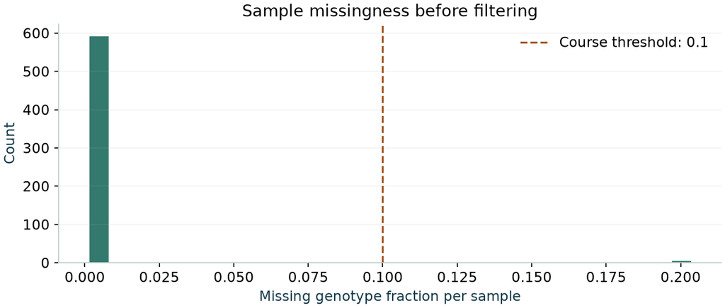

Actual demo diagnostic before QC filtering. Six samples have deliberately elevated missingness.

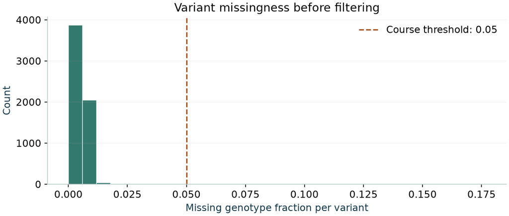

The denominator here is the number of samples, rather than the number of variants.

Explore the diagnostic

### Move the sample-missingness threshold.

Maximum missing fraction: 10%

**594**samples meeting this criterion

**6**samples above the threshold

Calculated from the 600 actual demo baseline missingness values. This browser exercise changes no files. Full-pipeline counts can differ after earlier filtering changes the denominator.

R · run in RStudio

```
smiss <- read_ws(file.path(cfg$qc, "before.smiss"))
vmiss <- read_ws(file.path(cfg$qc, "before.vmiss"))
par(mfrow = c(1, 2))
hist(as.numeric(smiss$F_MISS), breaks = 30, main = "Sample missingness", xlab = "Missing-call fraction")
abline(v = cfg$mind, col = "#B45309", lty = 2)
hist(as.numeric(vmiss$F_MISS), breaks = 30, main = "Variant missingness", xlab = "Missing-call fraction")
abline(v = cfg$geno, col = "#B45309", lty = 2)
par(mfrow = c(1, 1))
```

A sample has 9% missing calls; a variant has 6%. With mind = 0.10 and geno = 0.05, what passes?The sample passes; the variant fails.The sample fails; the variant passes.Both pass.

Step 05

## Apply one filter, then count.

The course uses teaching thresholds: variant missingness 5%, sample missingness 10%, and MAF 1%. These are choices to examine, not values to transfer automatically to any study.

### A. Variant missingness: --geno 0.05

Remove variants with missing calls in more than 5% of samples.

R · run in RStudio

```
geno <- file.path(cfg$qc, "02_geno")
run_plink(cfg, c("--bfile", start, "--geno", plink_number(cfg$geno), "--make-bed", "--out", geno))
record_counts(cfg, geno, "02_geno")
```

Demo checkpoint: **600 samples · 5970 variants**. Thirty deliberately poorly called variants are removed.

Prepare data in R

### B. Sample missingness: --mind 0.10

Now remove samples whose missing fraction exceeds 10% on the remaining variants.

R · run in RStudio

```
mind <- file.path(cfg$qc, "03_mind")
run_plink(cfg, c("--bfile", geno, "--mind", plink_number(cfg$mind), "--make-bed", "--out", mind))
record_counts(cfg, mind, "03_mind")
```

Demo checkpoint: **594 samples · 5970 variants**. Six samples are removed.

Prepare data in R

### C. Minor allele frequency: --maf 0.01

Remove variants with minor allele frequency below 1% in the current sample set. MAF is an allele frequency, not the proportion of people carrying the allele.

R · run in RStudio

```
maf <- file.path(cfg$qc, "04_maf")
run_plink(cfg, c("--bfile", mind, "--maf", plink_number(cfg$maf), "--make-bed", "--out", maf))
record_counts(cfg, maf, "04_maf")
```

Demo checkpoint: **594 samples · 5920 variants**. Fifty low-frequency variants are removed.

Prepare data in R

**Why can the order matter?**

Each filter is calculated using the samples and variants present at that step. Removing poorly called variants can reduce a sample’s measured missingness; removing samples can change allele frequencies. Keep the order and its count table with your results.

- I can explain which denominator is used by geno, mind and MAF.

Step 06

## Review unusual heterozygosity.

Estimate the inbreeding coefficient on common, approximately independent variants. LD pruning limits the influence of highly correlated markers. The pruned set is for diagnostics, not automatically the final association dataset.

R · run in RStudio

```
prune <- file.path(cfg$qc, "prune")
run_plink(cfg, c("--bfile", maf, "--maf", "0.05", "--indep-pairwise", "200", "50", "0.2",
                "--out", prune), paste0(prune, ".prune.in"))
run_plink(cfg, c("--bfile", maf, "--extract", paste0(prune, ".prune.in"),
                "--het", "--out", file.path(cfg$qc, "heterozygosity")),
          file.path(cfg$qc, "heterozygosity.het"))
het <- read_ws(file.path(cfg$qc, "heterozygosity.het"))
summary(as.numeric(het$F))
```

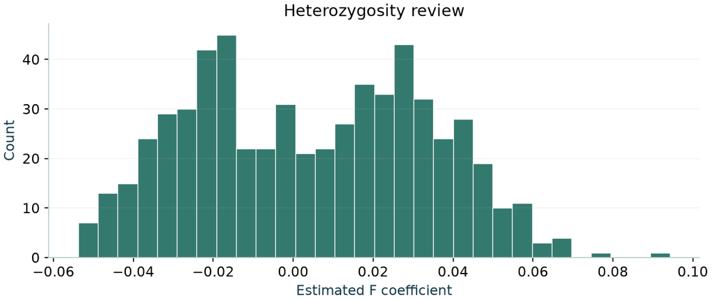

F compares observed and expected heterozygosity. Review the pattern together with structure and technical information.

R · run in RStudio

```
hist(as.numeric(het$F), breaks = 30, main = "Review heterozygosity", xlab = "F coefficient")
```

An unusual coefficient can reflect technical problems, ancestry or inbreeding. A pooled mean ±3 SD rule can remove valid samples from a heterogeneous cohort. This walkthrough reports the diagnostic without automatic heterozygosity exclusions.

**Going further: what else would you ask before excluding a sample?**

Review call quality, batch, contamination evidence, population structure and whether the coefficient was estimated using appropriate allele frequencies. Record the rationale and repeat downstream analysis after any justified exclusion.

Step 07

## Avoid treating close relatives as independent.

The simple association models later in the course assume independent observations. KING estimates genetic kinship and selects a subset avoiding pairs above the chosen threshold.

| Relationship | Approximate KING kinship |
| --- | --- |
| Duplicate / identical genotype | 0.50 |
| First degree | 0.25 |
| Second degree | 0.125 |
| Third degree | 0.0625 |

The teaching cutoff is `0.0884`, screening close relationships through roughly the second degree. Estimates are variable; KING kinship is not the same quantity as PI_HAT.

R · run in RStudio

```
king <- file.path(cfg$qc, "relatedness")
run_plink(cfg, c("--bfile", maf, "--extract", paste0(prune, ".prune.in"),
                "--king-cutoff", plink_number(cfg$kinship), "--out", king), paste0(king, ".king.cutoff.in.id"))
final <- file.path(cfg$qc, "qc_final")
# Apply the sample list to ALL QC-passing variants, not just the pruned subset.
run_plink(cfg, c("--bfile", maf, "--keep", paste0(king, ".king.cutoff.in.id"),
                "--make-bed", "--out", final))
record_counts(cfg, final, "05_unrelated")
read.delim(file.path(cfg$qc, "sample_variant_counts.tsv"))
```

**Check:** the demo finishes with 592 samples and 5920 variants. Two simulated duplicate pairs lead to two exclusions. Apply the retained *sample* list to all QC-passing variants, rather than keeping only the LD-pruned markers.

**How would sample selection change in a research study?**

Call quality, phenotype completeness and the study design can affect which relative should be retained. A mixed-model strategy may instead accommodate related observations. The automatic teaching subset is not a universal sample-priority rule.

Step 08

## Save a checkpoint you can explain.

Verified output for the default simulated walkthrough

| Stage | Samples | Variants |
| --- | --- | --- |
| 01_autosomes | 600 | 6000 |
| 02_geno | 600 | 5970 |
| 03_mind | 594 | 5970 |
| 04_maf | 594 | 5920 |
| 05_unrelated | 592 | 5920 |

Your checkpoint is `qc_final.bed/.bim/.fam`, alongside the prepared metadata, phenotype file and count table. Lesson 2 reloads these files; it does not require a saved R workspace.

Prepare data in R

### Before moving on

Explain why the sample count decreases at the relatedness step while the variant count remains the same. Then name the file you would inspect if the counts did not match your prediction.

**Compare your explanation**

The KING cutoff supplies a retained-sample list. It is applied to the full MAF-filtered set, so relatives can be removed without intentionally discarding its variants. Inspect the PLINK log and sample/variant count table; counts alone do not validate every QC decision.

- I have a complete final genotype set and can account for the exclusions.

## Ready for population structure.

Next, use the QC-passing data to calculate PCs, inspect structure and prepare an explicit analysis sample list.

[Open the PCA notebook](https://github.com/mgentiluomo/GWAS_training_session/blob/course/2026-guided-training/legacy/demo_2025/02_population_structure.Rmd)

← PreparationPractice and explain →

Module 01 · Practice

# Make the decisions yours.

Predict first. Run a separate comparison if you can. Use the explanation only after you have tried.

## 1. Call rate is not missingness

A new sample has a call rate of 94%. A protocol keeps samples with missingness at most 0.08. Does it pass this criterion? Show the conversion.

**Reveal a worked explanation**

Its missing fraction is `1 − 0.94 = 0.06`, or 6%. It passes the 8% missingness criterion. This says nothing about whether it passes other QC criteria.

## 2. A stricter cutoff

Before running a new command, predict what reducing `mind` from 0.10 to 0.05 can do to the retained sample set for the same input. Use a new output prefix such as `03_mind_stricter`; do not overwrite the core result.

**A hint, without running it**

The same input and denominator are essential. Ask whether a sample failing the original rule could pass a more restrictive version of that rule.

**Reveal the reasoning**

The number retained cannot increase for the same fixed input, though it may stay equal. The exact difference depends on the data. Repeating the whole pipeline can change other estimates, so separate the one-step comparison from a complete rerun.

## 3. The mixed file set

A BED file downloaded yesterday is combined with a BIM from another release. The names match and both files open. What would you check before running QC?

**Reveal the reasoning**

Check provenance and release, sample/variant order, dimensions and the BED signature/expected byte count. Equal dimensions alone cannot prove that the biological records are matched. Obtain a known matching set rather than relabelling files to bypass a check.

## 4. A problematic import

An exported file has header `FID;IID;Age` and a value `24,5`. Explain why renaming it to `.tsv` is insufficient. What information is needed before conversion?

**Reveal the reasoning**

Renaming does not change delimiters, decimal marks or encoding. Confirm the documented semicolon separator, decimal comma, missing-value coding, text encoding and identifier handling, then import with those settings and validate a new canonical output. Do not replace all commas blindly.

## Write your QC note

In five sentences, name the data mode and starting dimensions, explain two filtering choices, give the final dimensions, identify a diagnostic needing review and state one limitation of this walkthrough. Keep your note in your own lab notebook.

- I have written a QC interpretation, including a limitation.

This page does not submit answers or collect student records. Checklist ticks can remain in this browser; exercise responses are not saved or sent.

← Quality controlFiles and checkpoints →

Files and checkpoints

# The right files for the right step.

These are the older demo stages. Prepare demo data in R. Guided 2026 checkpoints come from the encrypted course release; it has not been published yet.

These packages match the default demo seed and tested build. They are not checkpoints for the original class dataset, or for a run whose sample selection or thresholds you changed. Back up an existing run before replacing outputs.

[Complete RStudio project](https://github.com/mgentiluomo/GWAS_training_session/archive/refs/heads/course/2026-guided-training.zip)[All three notebooks](https://github.com/mgentiluomo/GWAS_training_session/tree/course/2026-guided-training/lessons)

### Initial demo input

Use matching data prepared in R; no public ZIP is supplied here.

Prepare data in R

### After autosomal preparation

Use matching data prepared in R; no public ZIP is supplied here.

Prepare data in R

### After variant-missingness filtering

Use matching data prepared in R; no public ZIP is supplied here.

Prepare data in R

### After sample-missingness filtering

Use matching data prepared in R; no public ZIP is supplied here.

Prepare data in R

### After minor-allele-frequency filtering

Use matching data prepared in R; no public ZIP is supplied here.

Prepare data in R

### Final QC checkpoint

Use matching data prepared in R; no public ZIP is supplied here.

Prepare data in R

## Resume without restoring an old workspace

1. Keep the first error and the log from the run that stopped.
2. Back up the affected outputs. Use the matching complete checkpoint for the last completed step. The setup instructions explain access.
3. Open the RStudio project and restart R. Run the setup below.
4. Use the individual command block for the next step on this web page, or select those lines in the notebook. An intermediate package does not contain every earlier diagnostic or genotype set.

R · restore path variables only

```
root <- if (file.exists("R/course.R")) "." else ".."
source(file.path(root, "R", "course.R"))
cfg <- course_config(root)
start <- file.path(cfg$qc, "01_autosomes")
geno <- file.path(cfg$qc, "02_geno")
mind <- file.path(cfg$qc, "03_mind")
maf <- file.path(cfg$qc, "04_maf")
prune <- file.path(cfg$qc, "prune")
king <- file.path(cfg$qc, "relatedness")
final <- file.path(cfg$qc, "qc_final")
```

For a full restart, restore the initial demo inputs and begin the QC walkthrough at step 1. To join lesson 2 directly, use the final QC checkpoint and open its notebook.

## What is inside a checkpoint?

The matching BED/BIM/FAM set for that stage, prepared metadata, phenotype and sex tables, a stage-appropriate count table and a manifest with SHA-256 checksums. It does not include a saved R workspace or the original study data.

Release URLs and expected checksums are configured in config.R. See the setup instructions above.

## The original class data

The original BED is distributed through the course’s institutional access arrangements. Older links may expire or require authentication. Use only its matching BIM/FAM files and authorised checkpoints.

[Read original-data access and coding instructions →](https://github.com/mgentiluomo/GWAS_training_session/blob/course/2026-guided-training/docs/data.md)

← PracticeTroubleshooting →

Troubleshooting

# Keep the first error. Find a way back in.

A technical problem does not need to end your participation. You can read the examples, interpret outputs and rejoin from a matching checkpoint.

## When a chunk stops

1. Do not run later chunks yet.
2. Read the first error, not just the last line.
3. Inspect the input or log named in that message.
4. Use the relevant check below, or a checkpoint if the class is moving on.

**R cannot open R/course.R**

Open the complete RStudio project. In the console, `file.exists("config.R")` should be TRUE. Do not move the notebook into a separate folder or translate folder names by hand.

**PLINK 2 was not found**

Extract the executable from its ZIP and place it directly in `bin/`: plink2.exe on Windows, plink2 on macOS/Linux. A PLINK 1.9 executable is not sufficient. Confirm that the build matches your OS and CPU.

**A downloaded program cannot execute**

Check CPU architecture, file permissions and the operating system’s normal approval process for a trusted official download. On macOS/Linux, `Sys.chmod("bin/plink2", "0755")` grants executable permission to that file. Do not disable security globally.

**BED header or size does not match**

Check whether a login webpage was saved instead of binary data. Confirm that BED, BIM and FAM are from the same release. Obtain the matching set; do not rename unrelated files to pass the check.

**The table has one column, or a number is rejected**

Check the actual delimiter, decimal mark and text encoding. Course metadata are UTF-8 TSV with decimal points. A semicolon CSV or decimal comma needs a documented separate import. Avoid an Excel open-and-resave round trip on analytical inputs.

**Sample IDs are duplicated or do not match**

Inspect the FID/IID pairs as text, including initial zeros. Resolve the data provenance. Do not join by row number or discard an identifier to force a match.

**A file exists but a variable is not found**

Files on disk and objects in R memory are different. Start with the notebook’s setup chunk. If restoring an intermediate package, run the path-variable setup on the Downloads page, then execute the next individual step.

**My count differs from the example**

Confirm demo mode, the original seed, filtering order and settings. Check the count table and the first differing PLINK log. The published numbers are for the default simulation, not the original study or an intentionally modified exercise.

**A path with spaces or other alphabets fails**

The course constructs and quotes paths, but platform verification is still needed. Preserve your original copy and try a short writable project location, such as C:/gwas_training on Windows or a gwas_training folder in your home directory. Rerun preflight and retain its report.

**Knit fails but individual chunks work**

The analytical code and HTML rendering have different dependencies. Run `source("scripts/install_packages.R")` and check knitr, rmarkdown and Pandoc. RStudio normally includes Pandoc. Continue reading this web tutorial while resolving the preview.

## Rejoin the lesson

Download a checkpoint for the same data mode, restore its complete file set and record which results were supplied. You can then interpret the next step with the class and return to the original error later.

Choose a checkpointRead the worked walkthrough

← Files and checkpointsGlossary →

Quick reference

# A small glossary for the practical work.

| Term | Meaning |
| --- | --- |
| Genotype | The observed alleles for one sample at one position. |
| FID / IID | The identifier pair used to match samples across files. |
| Call rate | The fraction of successfully called genotypes: one minus missingness. |
| MAF | Minor allele frequency in the samples used for the estimate. |
| LD | Association between alleles at different loci; linked SNPs can carry correlated information. |
| LD pruning | Selecting an approximately independent subset for an analysis such as PCA. |
| Heterozygosity | The presence of two different alleles at a diploid locus. |
| KING kinship | An estimate of genetic relationship; duplicates are near 0.5 on this scale. |
| HWE | A population-genetic expectation for genotype proportions; departures need contextual interpretation. |
| PCA / PC | Principal component analysis and the components summarising genetic variation. |
| Covariate | An additional predictor, such as age or a PC, included in a statistical model. |
| OR | Odds ratio per extra copy of the counted allele in an additive logistic model. |
| A1 | The counted allele reported by the association output; do not assume it is always the minor allele. |
| Confidence interval | A range expressing uncertainty under the model’s assumptions. |
| p-value | Under the null model, the probability of a statistic at least as extreme as observed. |
| Checkpoint | A matching set of saved files from a defined stage, not a guarantee of scientific validity. |

[Open the extended repository glossary →](https://github.com/mgentiluomo/GWAS_training_session/blob/course/2026-guided-training/docs/glossary.md)

## Reference documentation

- [PLINK filtering](https://www.cog-genomics.org/plink/2.0/filter)
- [PLINK quality-control statistics](https://www.cog-genomics.org/plink/2.0/basic_stats)
- [KING kinship](https://www.cog-genomics.org/plink/2.0/distance)
- [R file delimiters and decimal marks](https://stat.ethz.ch/R-manual/R-devel/library/utils/html/read.table.html)

← TroubleshootingTutorial home →